# Machine Learning

Shammunul Islam

Thursday, October 11, 2018

### Poisson and Quasipoisson

These models can be used for predicting counts. Poisson model has the assumption that mean is equal variance, if that condition is not hold, we can use quasipoisson model.

**glm(formula, data, family)**

**glm(y ~ x1 + x2 + x3, dataset, family = quasipoisson)**

### Generalized additive model (GAM)

If we are not sure about the nonlinear relationship between independent and dependent variable, we can use GAM to learn the nonlinear nature of the relationship.

In the **gam()** function, we can use family = gaussian for regular regression, binomial for probabilities and poisson/quasipoisson for count data.

```r
# library(mgcv)
# gam(dependent ~ s(independent), data = train, family = gaussian)
```

We use **s()** to denote that there is a nonlinear relationship etween this predictor variable and reponse variable. We can’t use **s()** with categorical variable.

### Machine Learning

“Machine learning is a field of artificial intelligence that uses statistical techniques to give computer systems the ability to”learn" (e.g., progressively improve performance on a specific task) from data, without being explicitly programmed." – Wikipedia

Given input and output data, it wants to estimate the function that best emulate or approximaes the relationship between them that lead to the response.

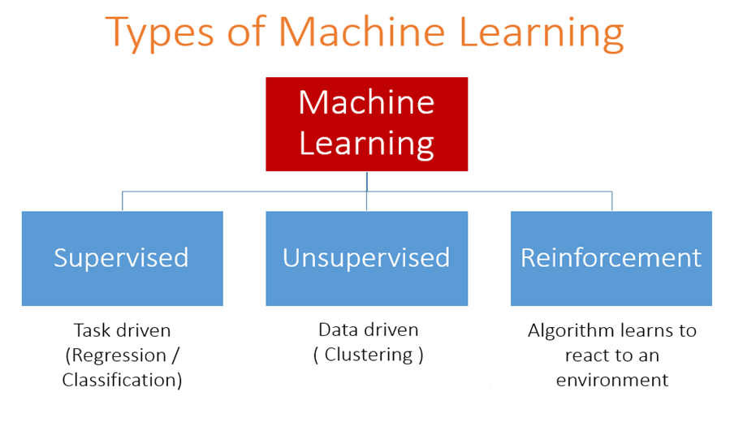

Today, we will cover supervised machine learning.

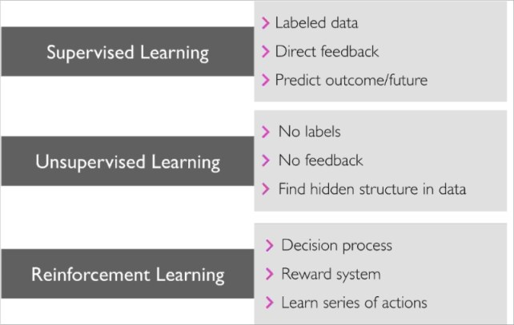

#### So, have we covered any of ML so far, what is your take?

### Some common machine learning tasks:

- Classification
- Regression
- Clustering

### Bias/variance trade off

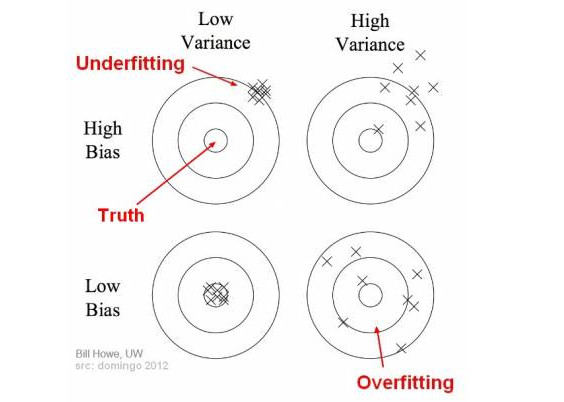

High bias results in underfitting and low variance and low bias results in overfitting (or close to) which will have high variance.

### Training, test and validation data

- Training data: The model is initially fit on a training dataset.
- Validation data: this dataset is used to predict the response of the obsservations. This dataset can be used more than once for model selection among other competing models.
- Test data: We evaluate our model by fitting it on test data for once.

#### Cross-validation: techniques for assessing how the results of a statistical analysis will generalize to an independent data set. It estimates the skill of a machine learning model on unseen data.

#### k-Fold Cross-Validation

### Creating training and testing data

```r
library(ISLR)
names(Smarket)
```

```
## [1] "Year"      "Lag1"      "Lag2"      "Lag3"      "Lag4"      "Lag5"
## [7] "Volume"    "Today"     "Direction"
```

```r
library(rpart)

# Shuffle the dataset; build train and test
n = nrow(Smarket)
shuffled = Smarket[sample(n),]
train = shuffled[1:round(0.7 * n),]
test = shuffled[(round(0.7 * n) + 1):n,]


tree = rpart(Direction ~ ., train, method = "class")

# Predict the outcome
pred = predict(tree, test, type = "class")

# Calculate the confusion matrix: conf
conf = table(test$Direction, pred)

# Print this confusion matrix
print(conf)
```

```
##       pred
##        Down  Up
##   Down  189   0
##   Up      0 186
```

100% accuracy!?

Let’s work with Carseats dataset now.

```r
library(ISLR)
attach(Carseats)
library(tidyverse)
Carseats = Carseats %>%
  mutate(High = ifelse(Sales <= 8, "No", "Yes"))

# Shuffle the dataset; build train and test
n = nrow(Carseats)
shuffled = Carseats[sample(n),]
train = shuffled[1:round(0.7 * n),]
test = shuffled[(round(0.7 * n) + 1):n,]
tree = rpart(High~.-Sales, train, method = "class")
pred = predict(tree, test, type = "class")
conf = table(test$High, pred)
print(conf)
```

```
##      pred
##       No Yes
##   No  63  12
##   Yes 19  26
```

```r
# Accuracy
sum(diag(conf))/sum(conf)
```

```
## [1] 0.7416667
```

#### 6-fold cross validation

We will use 6-fold cross validation and calculate the accuracy for each fold. The mean of these accuracies is a robust estimation of the model’s true accuracy in predicting unseen data.

```r
set.seed(1)
holder = rep(0,6)
for (i in 1:6) {
  # Interval of the test set
  indices = (((i-1) * round((1/6)*nrow(shuffled))) + 1):((i*round((1/6) * nrow(shuffled))))
  train = shuffled[-indices,]
  test = shuffled[indices,]
  tree = rpart(High~.-Sales, train, method = "class")
  pred = predict(tree, test, type = "class")
  conf = table(test$High, pred)
  holder[i] = sum(diag(conf))/sum(conf)
}
mean(holder)
```

```
## [1] 0.740222
```

### Decision tree

```r
library(rpart)
library(rattle)
```

```r
library(rpart.plot)
library(RColorBrewer)
```

[figure not shown]

```r
fancyRpartPlot(tree)
```

### Pruning the tree

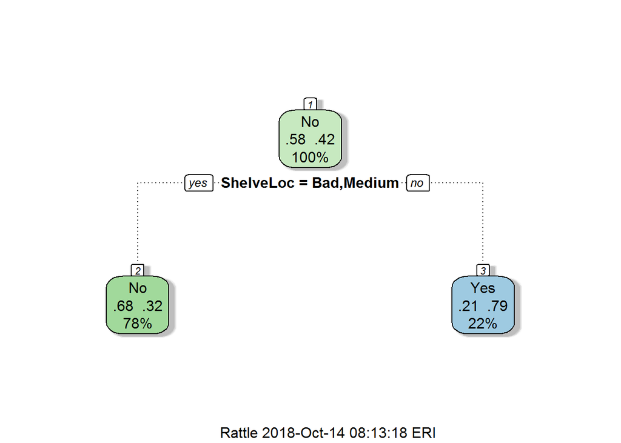

```r
tree = rpart(High~.-Sales, train, method = "class", control = rpart.control(cp=0.10))
fancyRpartPlot(tree)
```

### k-nearest neighbor

Consideration: Normalize data first

We will consider data for stock data upto 2004 for training and data after 2005 as test data.

**knn(predicors of training data, predictors of test data, vector of class labels for training oservations, number of narest neighbors)**

```r
library(dplyr)

train_knn = Smarket %>%
  filter(Year < 2005) %>%
  select(Lag1, Lag2)

test_knn = Smarket %>%
  filter(Year >= 2005)%>%
  select(Lag1, Lag2)

train_labels_knn = Smarket %>%
  filter(Year < 2005) %>%
  select(Direction) %>%
  .$Direction # returns the class labels as a vector rather than a dataframe

test_labels_knn = Smarket %>%
  filter(Year >= 2005) %>%
  select(Direction) %>%
  .$Direction # returns the class labels as a vector rather than a dataframe

library(class)
pred = knn(train = train_knn, test = test_knn, cl = train_labels_knn, k = 5)
# Confusion matrix
(conf = table(test_labels_knn, pred))
```

```
##                pred
## test_labels_knn Down Up
##            Down   40 71
##            Up     59 82
```

### Which k to choose?

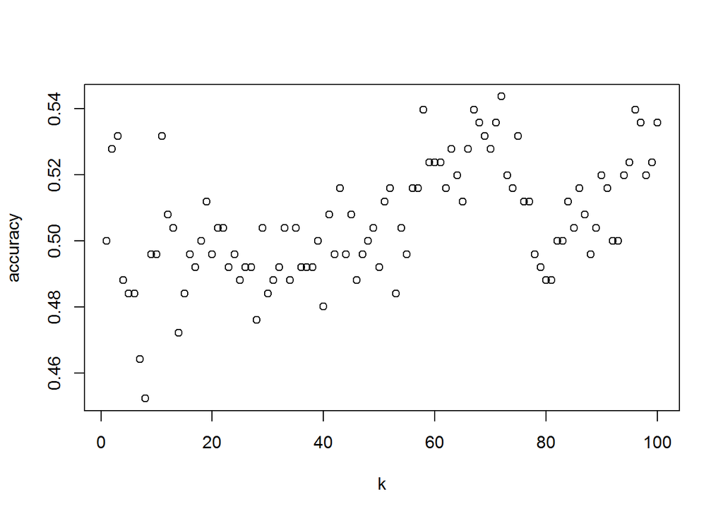

```r
#train_labels = train$High
#test_labels = test$High
library(class)
range = 1:round(0.1 * nrow(train_knn))
accuracy = rep(0, length(range))
for (k in range) {
  pred = knn(train = train_knn, test = test_knn, cl = train_labels_knn, k = k)
  # confusion matrix
  conf = table(test_labels_knn, pred)
  # accuracy
  accuracy[k] = sum(diag(conf)) / sum(conf)
}

# Plot the accuracies. Title of x-axis is "k".
plot(range, accuracy, xlab = "k")
```

```r
# Calculate the best k
which.max(accuracy)
```

```
## [1] 72
```

Let’s run again with new k.

```r
pred = knn(train = train_knn, test = test_knn, cl = train_labels_knn, k = 72)
# Confusion matrix
(conf = table(test_labels_knn, pred))
```

```
##                pred
## test_labels_knn Down Up
##            Down   47 64
##            Up     53 88
```

```r
# Accuracy
sum(diag(conf)) / sum(conf)
```

```
## [1] 0.5357143
```

The one that gives most accuracy.

### Can we measure the accuracy and conduct a 6-fold cross validation on this knn model?

### Receiver Operator Characteristic Curve

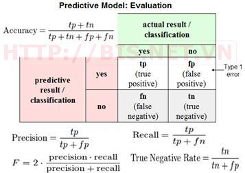

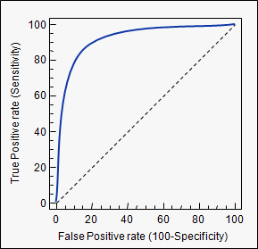

```r
library(rpart)
tree = rpart(High~.-Sales, train, method = "class")
probs = predict(tree, test, type = "prob")[,2]
library(ROCR)
```

```r
#train$High = ifelse(train$High == "Yes", 1, 0)
# test$High2 = ifelse(test$High == "Yes", 1, 0)
# pred = prediction(probs, test$High2)
#perf = performance(pred,  "tpr", "fpr")
# # AUC
# plot(perf)
```

### Regression trees

```r
library(tree)
library(MASS)
```

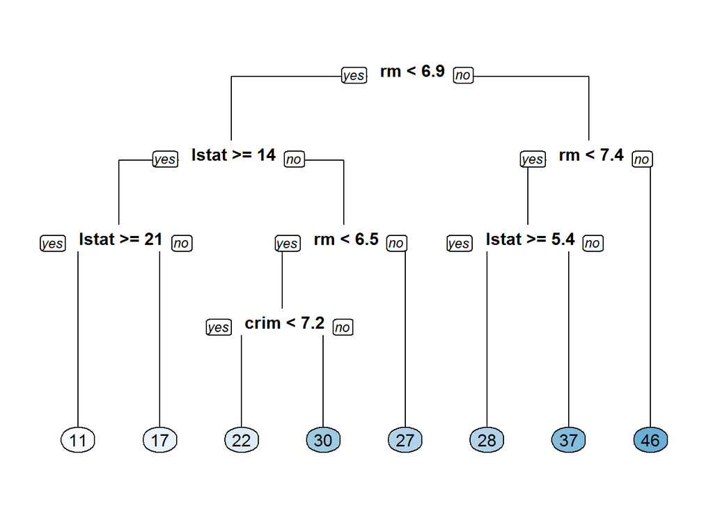

```r
set.seed(1)
n = nrow(Boston)
shuffled = Boston[sample(n),]
train_boston = shuffled[1:round(0.7 * n),]
test_boston = shuffled[(round(0.7 * n) + 1):n,]
tree.boston = rpart(medv~., train_boston, method = "anova")
rpart.plot(x = tree.boston, yesno = 2, type = 0, extra = 0)
```

Let’s work with decision tree again.

```r
tree = rpart(High~.-Sales, data = train, method = "class", control = rpart.control(cp=0.10))
```

We will get the confusion matrix now:

```r
Carseats = Carseats %>%
  mutate(High = ifelse(Sales <= 8, "No", "Yes"))

# We need to convert to factors the reponse variable
Carseats$High = as.factor(Carseats$High)

# Shuffle the dataset; build train and test
n = nrow(Carseats)
shuffled = Carseats[sample(n),]
train = shuffled[1:round(0.7 * n),]
test = shuffled[(round(0.7 * n) + 1):n,]

# Predict classes
class_prediction = predict(object = tree,
                        newdata = test,
                        type = "class")

library(caret)
# Confusion matrix
confusionMatrix(data = class_prediction,
                reference = test$High)
```

```
## Confusion Matrix and Statistics
##
##           Reference
## Prediction No Yes
##        No  66  30
##        Yes  8  16
##
##                Accuracy : 0.6833
##                  95% CI : (0.5922, 0.7652)
##     No Information Rate : 0.6167
##     P-Value [Acc > NIR] : 0.0782877
##
##                   Kappa : 0.2636
##  Mcnemar's Test P-Value : 0.0006577
##
##             Sensitivity : 0.8919
##             Specificity : 0.3478
##          Pos Pred Value : 0.6875
##          Neg Pred Value : 0.6667
##              Prevalence : 0.6167
##          Detection Rate : 0.5500
##    Detection Prevalence : 0.8000
##       Balanced Accuracy : 0.6199
##
##        'Positive' Class : No
##
```

### Impurity measures

- Entropy

Information gain = 1 - Impurity

- Gini Index

### Compare models with different impurity measures or splitting criterion

```r
# Gini
gini_model = rpart(formula = High~.-Sales,
                       data = train,
                       method = "class",
                       parms = list(split = "gini"))

# Information gain
information_model = rpart(formula = High~.-Sales,
                       data = train,
                       method = "class",
                       parms = list(split = "information"))

# Generate predictions on the validation set using the gini model
pred_gini = predict(object = gini_model,
                 newdata = test,
                 type = "class")

# Generate predictions on the validation set using the information model
pred_information = predict(object = information_model,
                 newdata = test,
                 type = "class")

library(Metrics)
# Compare classification error
ce(actual = test$High,
     predicted = pred_gini)
```

```
## [1] 0.2333333
```

```r
ce(actual = test$High,
     predicted = pred_information)
```

```
## [1] 0.2416667
```

### Pruning tree

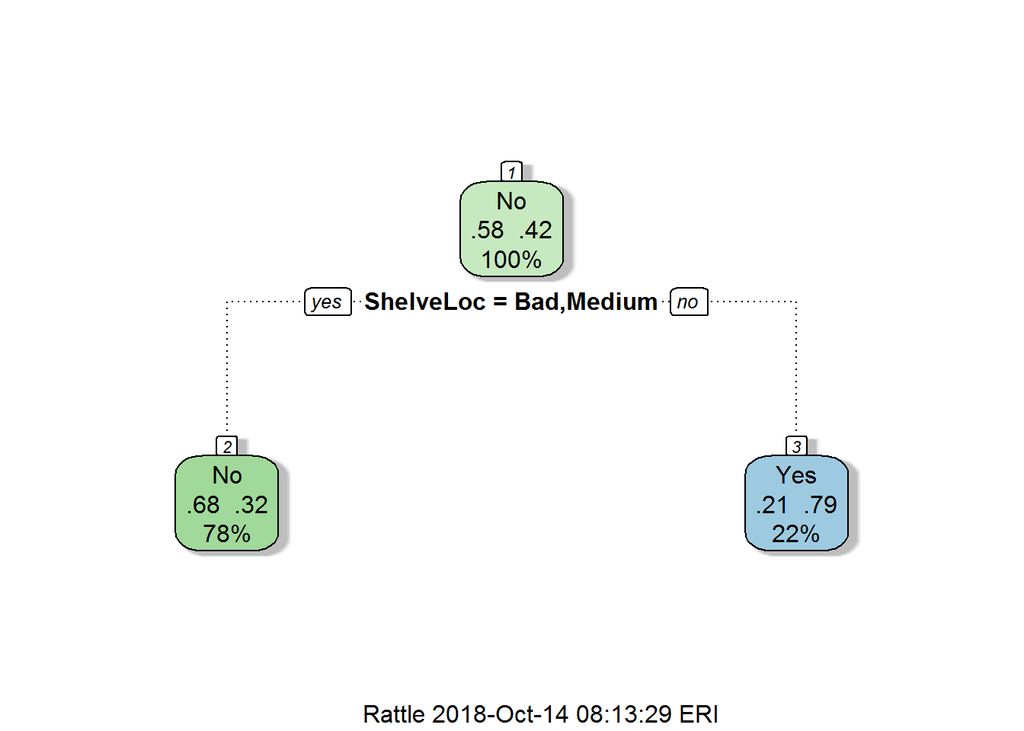

```r
pruned = prune(tree, cp = 0.01)

# Draw pruned
fancyRpartPlot(pruned)
```

### Cost-complexity parameter

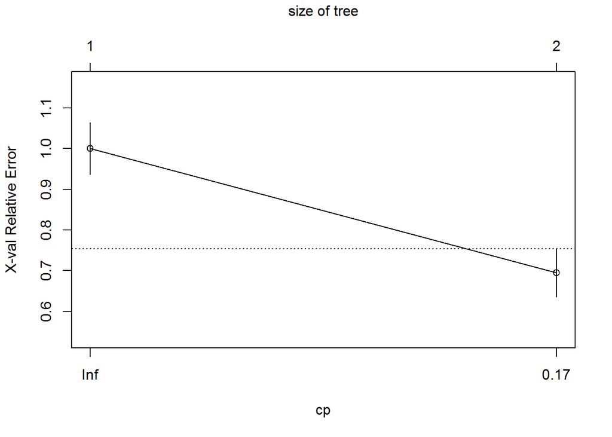

```r
plotcp(pruned)
```

### Retrieve optimal cp value and use it to fit a CART

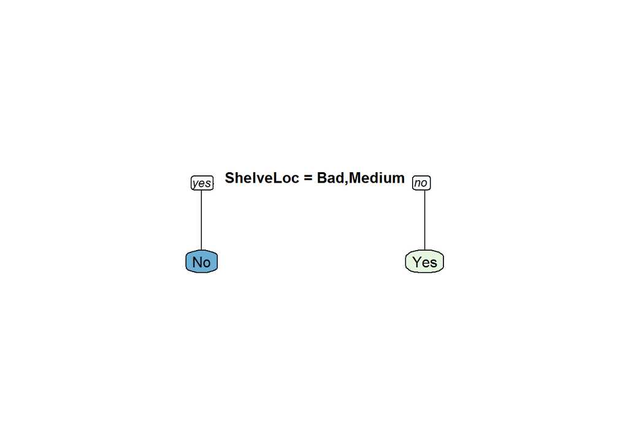

```r
# Optimal cp value
opt_index = which.min(tree$cptable[, "xerror"])
cp_opt = tree$cptable[opt_index, "CP"]

# Prune the model
tree_opt = prune(tree = tree,
                         cp = cp_opt)

# Plot the optimized model
rpart.plot(x = tree_opt, yesno = 2, type = 0, extra = 0)
```

### Bootstrap aggregation or Bagging

```r
library(ipred)
set.seed(123)
bagging_model = bagging(formula = High~.-Sales,
                        data = train,
                        coob = TRUE)

# Print the model
print(bagging_model)
```

```
##
## Bagging classification trees with 25 bootstrap replications
##
## Call: bagging.data.frame(formula = High ~ . - Sales, data = train,
##     coob = TRUE)
##
## Out-of-bag estimate of misclassification error:  0.0071
```

#### Prediction

```r
(class_prediction = predict(object = bagging_model,
                            newdata = test,
                            type = "class"))
```

```
##   [1] No  No  No  Yes No  No  No  Yes No  No  Yes Yes Yes Yes No  No  No
##  [18] Yes No  Yes No  No  Yes No  Yes No  Yes Yes No  No  No  Yes No  No
##  [35] Yes Yes Yes No  No  No  Yes No  Yes No  No  Yes Yes No  Yes Yes No
##  [52] No  Yes No  Yes Yes Yes No  No  Yes No  No  No  No  Yes No  No  No
##  [69] No  No  No  No  No  No  Yes Yes No  Yes No  No  No  Yes No  No  No
##  [86] No  No  No  No  Yes Yes No  No  Yes No  Yes Yes Yes No  Yes No  No
## [103] No  Yes Yes Yes No  Yes No  No  No  Yes No  Yes No  Yes No  No  No
## [120] No
## Levels: No Yes
```

#### Confusion matrix

```r
# Confusion matrix for the test set
confusionMatrix(data = class_prediction,
                reference = test$High)
```

```
## Confusion Matrix and Statistics
##
##           Reference
## Prediction No Yes
##        No  74   0
##        Yes  0  46
##
##                Accuracy : 1
##                  95% CI : (0.9697, 1)
##     No Information Rate : 0.6167
##     P-Value [Acc > NIR] : < 2.2e-16
##
##                   Kappa : 1
##  Mcnemar's Test P-Value : NA
##
##             Sensitivity : 1.0000
##             Specificity : 1.0000
##          Pos Pred Value : 1.0000
##          Neg Pred Value : 1.0000
##              Prevalence : 0.6167
##          Detection Rate : 0.6167
##    Detection Prevalence : 0.6167
##       Balanced Accuracy : 1.0000
##
##        'Positive' Class : No
##
```

### Gradient boosting

```r
library(gbm)
# Convert "yes" to 1, "no" to 0

# Shuffle the dataset; build train and test
n = nrow(Carseats)
shuffled = Carseats[sample(n),]
train = shuffled[1:round(0.7 * n),]
test = shuffled[(round(0.7 * n) + 1):n,]

train$High = ifelse(train$High == "Yes", 1, 0)

# Train on 300 trees for GBM
set.seed(1)
gbm_model = gbm(formula = High~.-Sales,
                    distribution = "bernoulli",
                    data = train,
                    n.trees = 10000)

print(gbm_model)
```

```
## gbm(formula = High ~ . - Sales, distribution = "bernoulli", data = train,
##     n.trees = 10000)
## A gradient boosted model with bernoulli loss function.
## 10000 iterations were performed.
## There were 10 predictors of which 10 had non-zero influence.
```

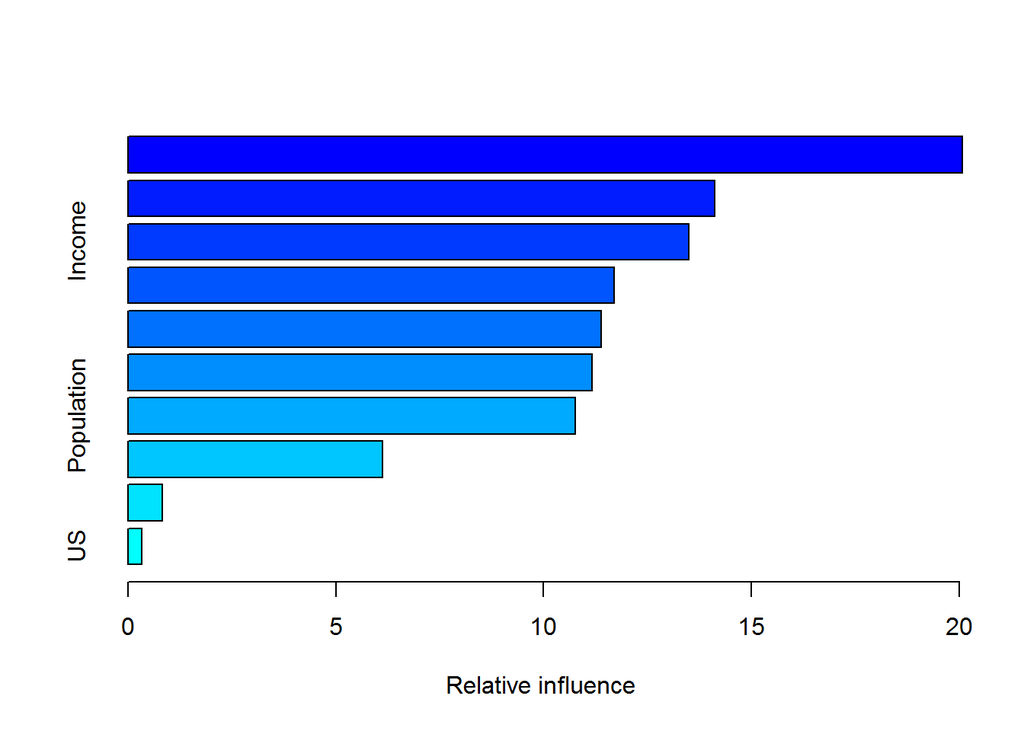

```
##                     var    rel.inf
## Price             Price 20.0701967
## ShelveLoc     ShelveLoc 14.1100413
## Income           Income 13.5007995
## CompPrice     CompPrice 11.6976050
## Advertising Advertising 11.3904484
## Age                 Age 11.1713583
## Population   Population 10.7677893
## Education     Education  6.1328972
## Urban             Urban  0.8323847
## US                   US  0.3264796
```

```r
# variable importance
summary(gbm_model)
```

Predict on the data

```r
predict(gbm_model, type = "response", n.trees = 10000)
```

[output not shown]

[output cut: 41 more lines]

### Predict on test data

```r
pred_val = predict(object = gbm_model,
                  newdata = test,
                  n.trees = 10000,
                  type = "response")
```

### GBM hyperparameters

```r
# train a GBM model
train$High = ifelse(train$High == "Yes", 1, 0)
test$High = ifelse(test$High == "Yes", 1, 0)
```

```r
# Optimal tree size based on CV error
#ntree_opt_cv = gbm.perf(gbm_model, method = "cv")
```

```r
# Optimal ntree based on OOB error
ntree_opt_oob = gbm.perf(gbm_model, method = "OOB")
```

```
## OOB generally underestimates the optimal number of iterations although predictive performance is reasonably competitive. Using cv_folds>1 when calling gbm usually results in improved predictive performance.
```

[figure not shown]

```r
pred = predict(object = gbm_model,
                  newdata = test,
                  n.trees = ntree_opt_oob)
```

### Random forest

```r
library(randomForest)
set.seed(1)
n = nrow(Carseats)
shuffled = Carseats[sample(n),]
train = shuffled[1:round(0.7 * n),]
test = shuffled[(round(0.7 * n) + 1):n,]
(rf_model = randomForest(formula = High~.-Sales,
                    data = train))
```

```
##
## Call:
##  randomForest(formula = High ~ . - Sales, data = train)
##                Type of random forest: classification
##                      Number of trees: 500
## No. of variables tried at each split: 3
##
##         OOB estimate of  error rate: 22.86%
## Confusion matrix:
##      No Yes class.error
## No  143  25   0.1488095
## Yes  39  73   0.3482143
```

### Predictions using test set

```r
pred = predict(object = rf_model,
                newdata = test,
                type = "prob")
head(pred)
```

```
##        No   Yes
## 285 0.726 0.274
## 232 0.582 0.418
## 317 0.180 0.820
## 199 0.850 0.150
## 374 0.852 0.148
## 314 0.506 0.494
```

### Support vector machine

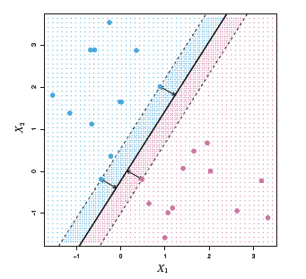

### Hyperplane

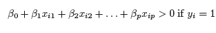

### Maximal Margin Classifier

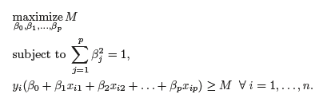

Let’s work with dataset linear.csv.

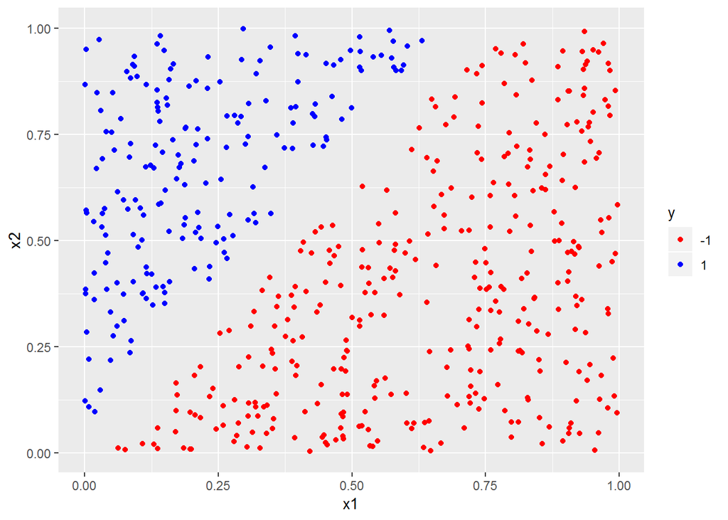

```r
data = read.csv("D:/Day 7/linear.csv")
# Remove column X as we don't need it
data$X = NULL
data$y = factor(data$y,
               levels = c(-1,1))
plot = ggplot(data = data, aes(x = x1, y = x2, color = y)) + geom_point() +
    scale_color_manual(values = c("red", "blue"))

plot
```

Let’s try to draw a decision boundary.

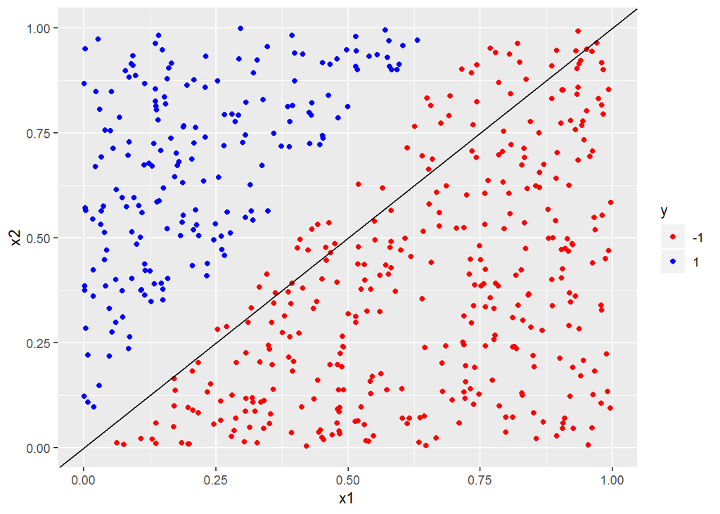

```r
plot = ggplot(data = data, aes(x = x1, y = x2, color = y)) + geom_point() +
    scale_color_manual(values = c("red", "blue")) +
    geom_abline(slope = 1, intercept = 0)

plot
```

Let’s try again with a new value of slope

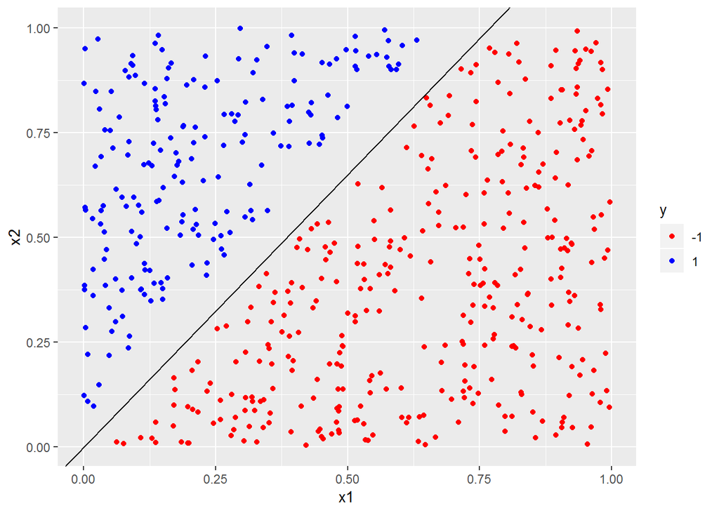

```r
plot = ggplot(data = data, aes(x = x1, y = x2, color = y)) + geom_point() +
    scale_color_manual(values = c("red", "blue")) +
    geom_abline(slope = 1.3, intercept = 0)

plot
```

Close, but we can do better. Let’s now try also to draw the margins:

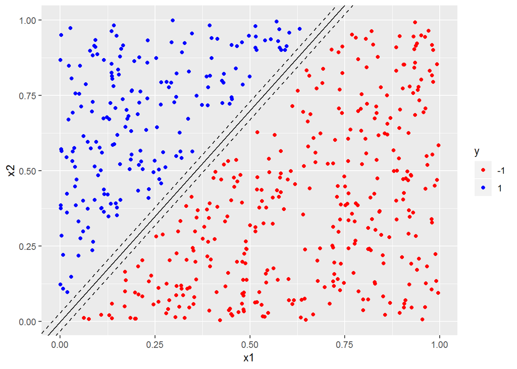

```r
plot = ggplot(data = data, aes(x = x1, y = x2, color = y)) + geom_point() +
    scale_color_manual(values = c("red", "blue")) +
    geom_abline(slope = 1.4, intercept = 0)+
    geom_abline(slope = 1.4, intercept = 0.03, linetype = "dashed") +
    geom_abline(slope = 1.4, intercept = -0.03, linetype = "dashed")

plot
```

Well, we see that this margin could be maximized further.

Now, let’s fit SVM model. But, before that make a split to get traning and test data.

```r
n = nrow(data)
shuffled = data[sample(n),]
train = shuffled[1:round(0.7 * n),]
test = shuffled[(round(0.7 * n) + 1):n,]
```

Fitting SVM model using **e1071** package.

```r
library(e1071)
svm_model = svm(y ~ ., data = train, type = "C-classification", kernel = "linear",
                scale = FALSE)
# See model output
svm_model
```

```
##
## Call:
## svm(formula = y ~ ., data = train, type = "C-classification",
##     kernel = "linear", scale = FALSE)
##
##
## Parameters:
##    SVM-Type:  C-classification
##  SVM-Kernel:  linear
##        cost:  1
##       gamma:  0.5
##
## Number of Support Vectors:  88
```

From this model, we can access support vector coordinates, support vector index, coefficients of the support vector (importance).

Support vector coordinates:

```r
svm_model$SV
```

```
##               x1         x2
## 221 0.4992728804 0.81280524
## 245 0.3367135401 0.67205829
## 174 0.0531294835 0.27624116
## 116 0.6034740848 0.95831828
## 154 0.4274944656 0.72502423
## 330 0.5825784358 0.90096529
## 53  0.2610879638 0.47258887
## 506 0.2056735931 0.43356675
## 90  0.2171576982 0.50504458
## 278 0.1078112544 0.37490846
## 24  0.4469696281 0.72133357
## 340 0.1084886545 0.37607909
## 212 0.0865806018 0.26371861
## 60  0.2712866147 0.56070785
```

[output cut: 74 more lines]

Support vector index:

```r
svm_model$index
```

```
##  [1]  19  20  27  29  41  46  77  99 119 130 135 138 142 143 147 157 160
## [18] 171 180 183 184 185 192 205 225 234 240 242 243 246 248 259 265 266
## [35] 289 291 294 308 322 332 363 366 369 378   4   5   9  13  15  17  24
## [52]  45  64  67  75  90  98 100 102 116 122 125 128 136 145 148 154 158
## [69] 173 193 199 201 202 256 268 273 278 281 301 306 307 309 323 340 355
## [86] 359 365 368
```

Support vector coefficients:

```r
svm_model$coefs
```

```
##             [,1]
##  [1,]  1.0000000
##  [2,]  1.0000000
##  [3,]  1.0000000
##  [4,]  1.0000000
##  [5,]  1.0000000
##  [6,]  1.0000000
##  [7,]  1.0000000
##  [8,]  1.0000000
##  [9,]  1.0000000
## [10,]  1.0000000
## [11,]  1.0000000
## [12,]  1.0000000
## [13,]  1.0000000
## [14,]  1.0000000
```

[output cut: 74 more lines]

Test accuracy

```r
pred_test = predict(svm_model, test)
mean(pred_test == test$y)
```

```
## [1] 1
```

### Visualizing support vectors

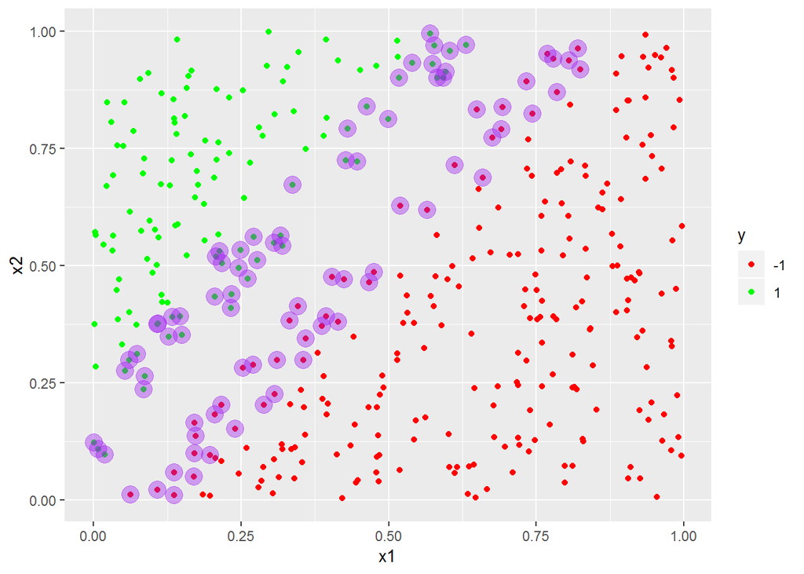

```r
sv = train[svm_model$index,]
p = ggplot(data = train, aes(x = x1, y = x2, color = y)) +
     geom_point() +
     scale_color_manual(values = c("red","green")) +
    geom_point(data = sv,
                    aes(x = x1, y = x2),
                    color = "purple",
                    size = 5, alpha = 0.4)
p
```

### plot() function

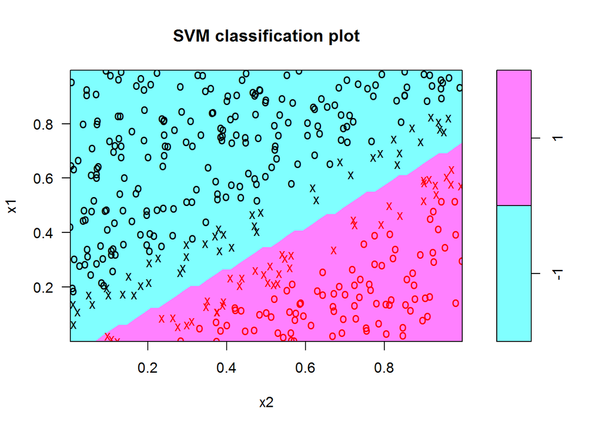

[figure not shown]

```r
plot(x = svm_model, data = train)
```

Now, we will work with radial.csv file.

```r
radial = read.csv("D:/Day 7/radial.csv")
radial$X = NULL
radial$y = factor(radial$y,
               levels = c(-1,1))
n = nrow(radial)
shuffled = radial[sample(n),]
train = shuffled[1:round(0.7 * n),]
test = shuffled[(round(0.7 * n) + 1):n,]
```

Let’s plot this data

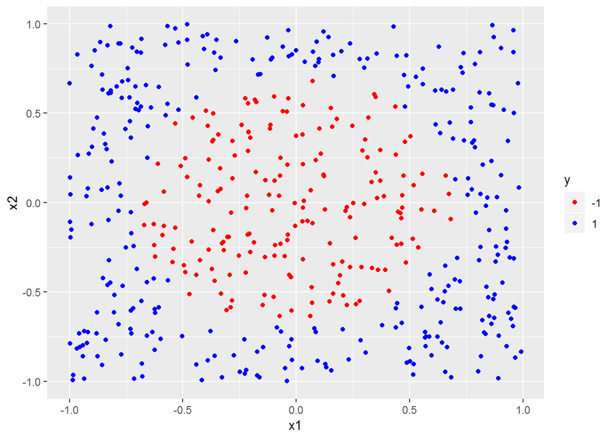

```r
p = ggplot(data = radial, aes(x = x1, y = x2, color = y)) +
     geom_point() +
     scale_color_manual(values = c("-1" = "red","1" = "blue"))

p
```

We can see that the data is not lineaarly separable. Even then, we will now fit a linear SVM.

```r
linear_1 = svm(y ~ ., data = train, type = "C-classification", cost = 1,
                   kernel = "linear", scale = FALSE)

linear_1
```

```
##
## Call:
## svm(formula = y ~ ., data = train, type = "C-classification",
##     cost = 1, kernel = "linear", scale = FALSE)
##
##
## Parameters:
##    SVM-Type:  C-classification
##  SVM-Kernel:  linear
##        cost:  1
##       gamma:  0.5
##
## Number of Support Vectors:  270
```

Let’s plot the model

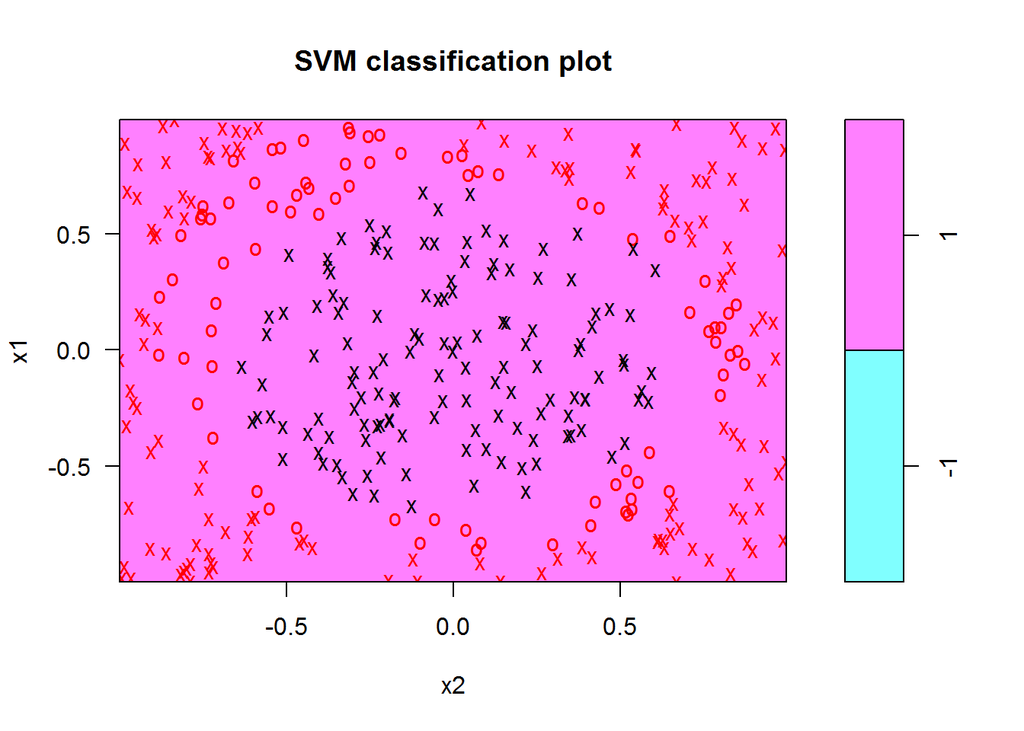

```r
plot(linear_1, train)
```

We can see that this model has classified all the points to a single class only.

#### Accuracy

```r
test_class = predict(linear_1, test)
mean(test_class == test$y)
```

```
## [1] 0.6533333
```

Now, try the same model with higher cost.

```r
linear_2 = svm(y ~ ., data = train, type = "C-classification", cost = 100,
                   kernel = "linear", scale = FALSE)
linear_2
```

```
##
## Call:
## svm(formula = y ~ ., data = train, type = "C-classification",
##     cost = 100, kernel = "linear", scale = FALSE)
##
##
## Parameters:
##    SVM-Type:  C-classification
##  SVM-Kernel:  linear
##        cost:  100
##       gamma:  0.5
##
## Number of Support Vectors:  281
```

Let’s plot this new model with higher value of cost.

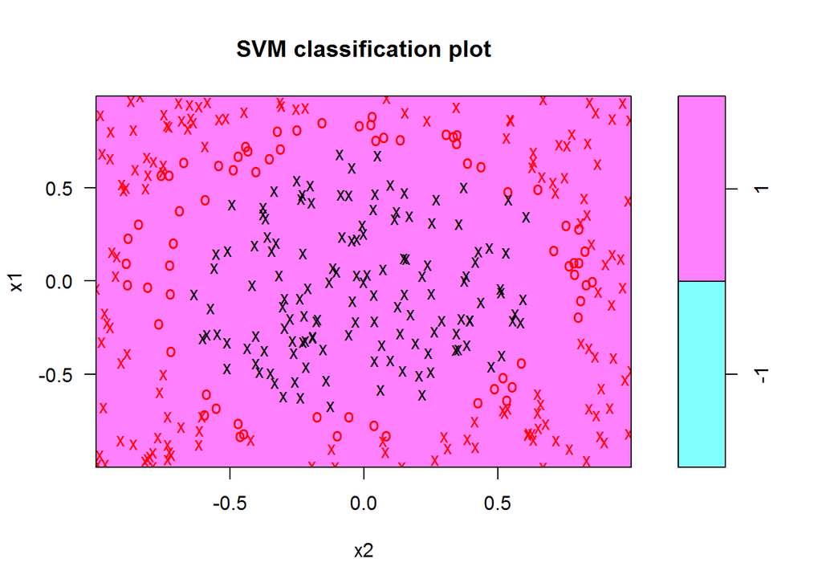

```r
plot(linear_2, train)
```

Accuracy of the second model

```r
test_class = predict(linear_2, test)
mean(test_class == test$y)
```

```
## [1] 0.6533333
```

### Kernel to rescue

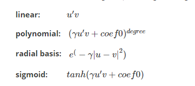

### Tuning the model

```r
tuned =
  tune.svm(x = train[,-3], y = train[,3],
        type = "C-classification", kernel = "polynomial", degree = 2,
        cost = 10^(-1:3), gamma = c(0.1,1,10, 100), coef0 = c(0.1,1,10, 100))
```

#### Tuned parameters – best Cost

```r
tuned$best.parameters$cost
```

```
## [1] 0.1
```

Best gamma

```r
tuned$best.parameters$gamma
```

```
## [1] 100
```

Best coef

```r
tuned$best.parameters$coef0
```

```
## [1] 1
```

Now fit with these tuned parameter values

```r
svm_model = svm(y~ ., data = train, type = "C-classification",
        kernel = "polynomial", degree = 2,
        cost = tuned$best.parameters$cost,
        gamma = tuned$best.parameters$gamma,
        coef0 = tuned$best.parameters$coef0)
```

#### Prediction accuracy

```r
test_pred = predict(svm_model, test)
mean(test_pred == test$y)
```

```
## [1] 0.9733333
```

SVM plot

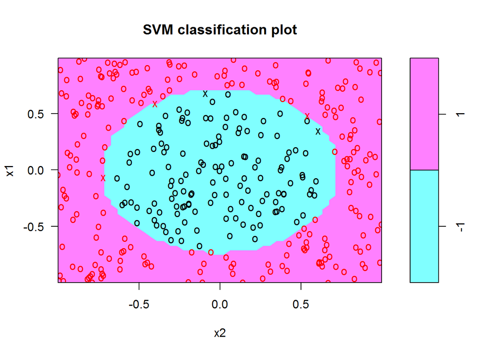

```r
plot(svm_model, train)
```

### Radial Basis Function Kernels

```r
radial = svm(y ~ ., data = train, type = "C-classification", kernel = "radial")
```

Test accuracy

```r
test_class = predict(radial, test)
mean(test_class == test$y)
```

```
## [1] 0.96
```

Let’s plot it

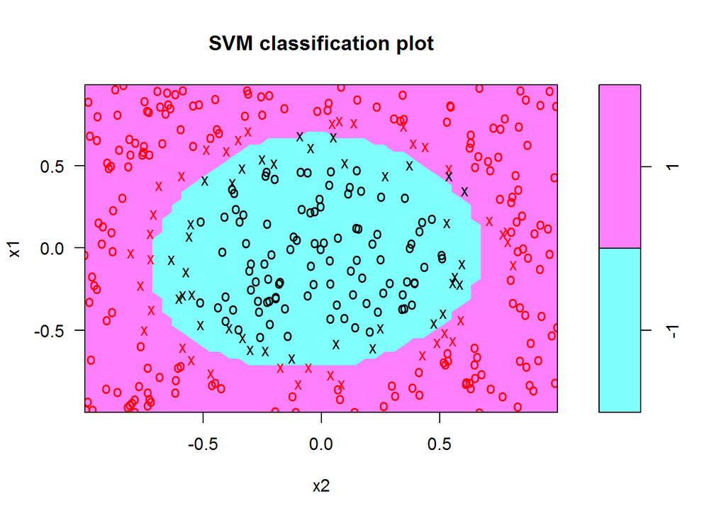

```r
plot(radial, train)
```